# Homework: Two Useful Functions

Marisa Mackie

2023-04-04

### Introduction

In this document I will be showing two useful functions.

- Function 1: Summary Statistics of Data Grouped by 2 Variables
- Function 2: Creating Bar Plot

### Libraries

```r
# Load libraries
library(tidyverse)
library(here)
library(palmerpenguins)
```

### Data

We will be using the palmerpenguins dataset.

```r
glimpse(penguins)
```

```
## Rows: 344
## Columns: 8
## $ species           <fct> Adelie, Adelie, Adelie, Adelie, Adelie, Adelie, Adel…
## $ island            <fct> Torgersen, Torgersen, Torgersen, Torgersen, Torgerse…
## $ bill_length_mm    <dbl> 39.1, 39.5, 40.3, NA, 36.7, 39.3, 38.9, 39.2, 34.1, …
## $ bill_depth_mm     <dbl> 18.7, 17.4, 18.0, NA, 19.3, 20.6, 17.8, 19.6, 18.1, …
## $ flipper_length_mm <int> 181, 186, 195, NA, 193, 190, 181, 195, 193, 190, 186…
## $ body_mass_g       <int> 3750, 3800, 3250, NA, 3450, 3650, 3625, 4675, 3475, …
## $ sex               <fct> male, female, female, NA, female, male, female, male…
## $ year              <int> 2007, 2007, 2007, 2007, 2007, 2007, 2007, 2007, 2007…
```

### Function #1: Statistics when Grouped by 2 Variables

#### df_stats2()

With this function, you can create a new dataframe showing summary statistics of your data, such that you are grouping by only 2 variables.

*Note: This function will drop missing (NA) values*

The arguments of this function include:

- data = the data you want to use
- gv1 & gv2 = the 2 variables you would like to group by (“grouping variables”)
- x = the variable you would like to calculate summary statistics for

```r
# Variables: gv1 and gv2 are the two variables you wish to group by
# x is the variable you would like to calculate summary statistics for

df_stats2 <- function(data, gv1, gv2, x) { # specifies fxn name & args

  df <- data %>% # grabs from data

  drop_na() %>% # drops NA values

  group_by({{gv1}},{{gv2}}) %>% # groups by 2 variables

  summarize(n = nrow({{x}}), # count
            avg = mean({{x}}, na.rm = TRUE), # averages data
            variance = var({{x}}, na.rm = TRUE), # calculates variance
            std_dev = sd({{x}}, na.rm = TRUE)) # calculates standard deviation

  return(df) # returns dataframe

}
```

Let’s test it with our penguin data:

I would like to group by (1) species and (2) sex, and I want to calculate summary statistics for flipper length.

```r
# Create new dataframe "peng_stats" using df_stats2 function to our penguin data.
peng_stats <- df_stats2(data = penguins, gv1 = species, gv2 = sex, x = flipper_length_mm)

glimpse(peng_stats)
```

```
## Rows: 6
## Columns: 5
## Groups: species [3]
## $ species  <fct> Adelie, Adelie, Chinstrap, Chinstrap, Gentoo, Gentoo
## $ sex      <fct> female, male, female, male, female, male
## $ avg      <dbl> 187.7945, 192.4110, 191.7353, 199.9118, 212.7069, 221.5410
## $ variance <dbl> 31.30441, 43.55099, 33.10963, 35.71925, 15.19328, 32.18579
## $ std_dev  <dbl> 5.595035, 6.599317, 5.754096, 5.976558, 3.897856, 5.673252
```

### Function #2: Creating Bar Plot

#### barplot()

With this function, you can plot your data as a basic bar plot.

```r
barplot <- function(data, x, y, fill, plot_title, x_axis, y_axis, legend_title){ # specifies fxn name & args

  plot <- data %>%

    # generates plot & specifies variables based on input
    ggplot(data, mapping = aes(x = {{x}},
                               y = {{y}},
                               fill = {{fill}}))+

    geom_bar(stat = "identity", position = "dodge")+ # specifies bar plot

    # specifies size & color of plot elements
    theme(plot.title = element_text(size = 15, face = "bold"),
          axis.title = element_text(size = 12, color = "saddlebrown"),
          legend.title = element_text(size = 10, color = "saddlebrown"),
          panel.background = element_rect(fill = "lightcyan"))+

    # specifies plot labels based on input
    labs(title = plot_title,
         x = x_axis,
         y = y_axis,
         fill = legend_title)

  return(plot) # returns plot
}
```

Let’s test it with the peng_stats data output from Function 1.

I will be using this function to plot the average flipper length for each species, between sexes. I will also specify the titles of the plot, axes, and legend that I want.

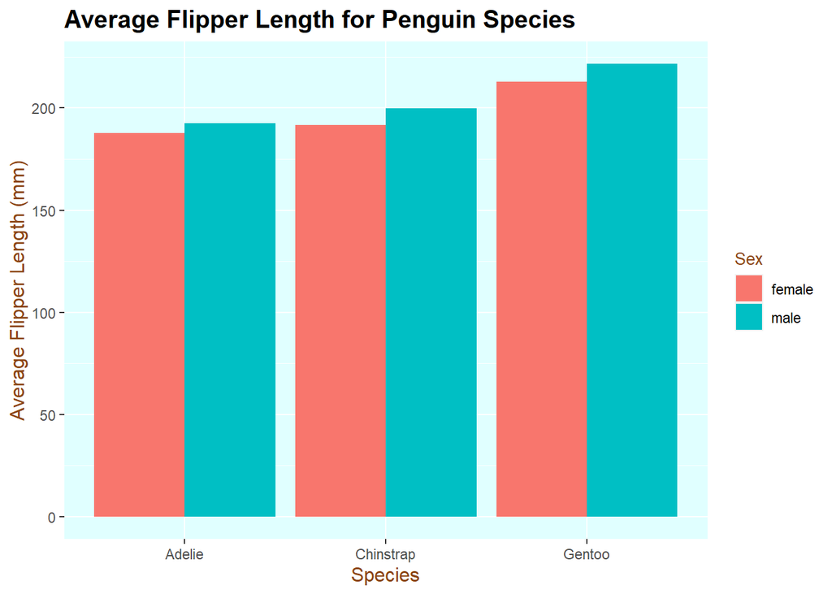

```r
# Uses barplot function to plot desired data
barplot(data = peng_stats, x = species, y = avg, fill = sex, plot_title = "Average Flipper Length for Penguin Species", x_axis = "Species", y_axis = "Average Flipper Length (mm)", legend_title = "Sex")
```

```r
# saves plot to output folder
ggsave(here("Week_09","output","ExamplePlotForFunction2.png"))
```